# White Wine Analysis by Peter Predtechensky

How will the plots look like if I don’t make quality bins? Let’s try to make the ‘quality’ variable a factor itself and take another look at some data:

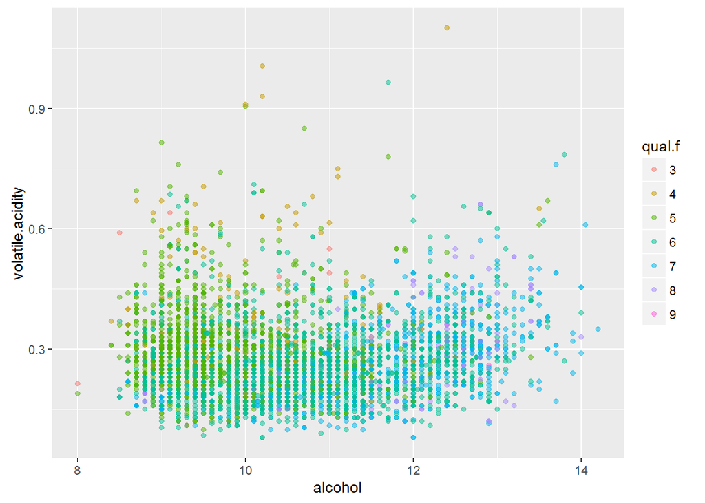

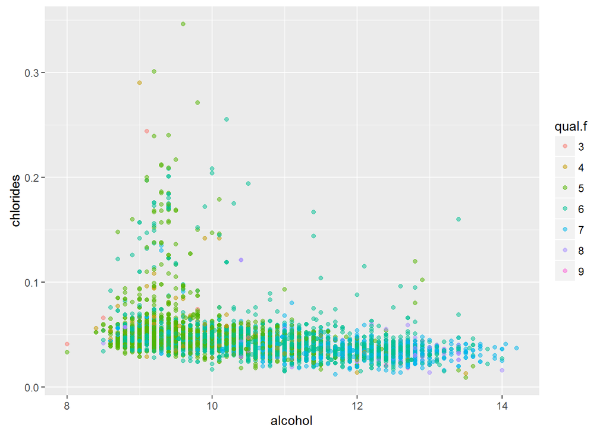

I see from the second picture that chlorides have a higher variation for Bad and Moderate wines. Let’s double-check this hypothesis:

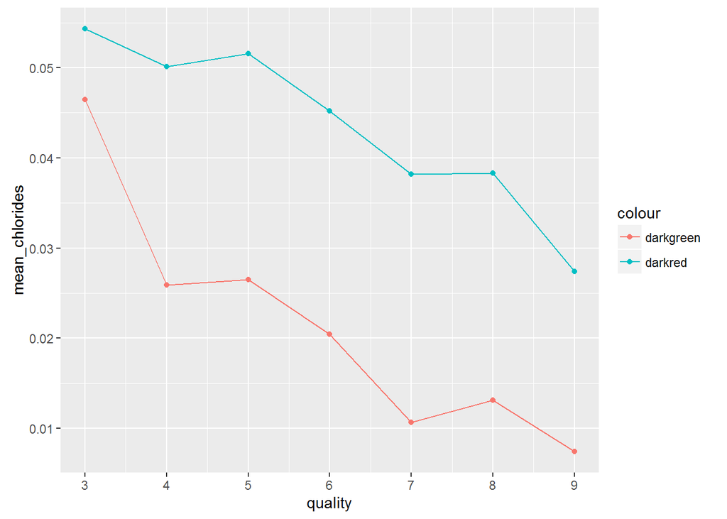

Right!!! Earlier I noticed from ggpairs() that there is a slight relationship between ‘chlorides’ and ‘quality’ (r = -0.21), so I’m not suprised that the mean declines. In addition to it I now clearly see from the plot that the Chlorides standard deviation declines with the wine quality growth.

Measuring the wine quality should be a pretty subjective task. There are a lot of Moderate quality wines that bring a lot of noise to my plots. What if I limit the dataset only to ‘Bad’ and ‘Good’ wines? How will my relationship look like?

```
##
##  Pearson's product-moment correlation
##
## data:  quality and alcohol/fixed.acidity
## t = 9.524, df = 361, p-value < 2.2e-16
## alternative hypothesis: true correlation is not equal to 0
## 95 percent confidence interval:
##  0.3618756 0.5267532
## sample estimates:
##      cor
## 0.448117
```

```
##
##  Pearson's product-moment correlation
##
## data:  quality and alcohol/volatile.acidity
## t = 9.3878, df = 361, p-value < 2.2e-16
## alternative hypothesis: true correlation is not equal to 0
## 95 percent confidence interval:
##  0.3562833 0.5220988
## sample estimates:
##       cor
## 0.4429714
```

```
##
##  Pearson's product-moment correlation
##
## data:  quality and citric.acid/free.sulfur.dioxide
## t = -6.3842, df = 361, p-value = 5.298e-10
## alternative hypothesis: true correlation is not equal to 0
## 95 percent confidence interval:
##  -0.4080663 -0.2228858
## sample estimates:
##        cor
## -0.3185117
```

```
##
##  Pearson's product-moment correlation
##
## data:  quality and alcohol/chlorides
## t = 8.3661, df = 361, p-value = 1.319e-15
## alternative hypothesis: true correlation is not equal to 0
## 95 percent confidence interval:
##  0.3130358 0.4857677
## sample estimates:
##       cor
## 0.4029843
```

Correlation coefficients noticeably improved: - r for quality and ratio of alcohol / fixed.acidity = 0.4481; - r for quality and ratio of alcohol / volatile.acidity = 0.443; - r for quality and ratio of citric.acid / free.sulfur.dioxide = -0.3185; - r for quality and ratio of alcohol / chlorides = 0.403;

### OPTIONAL: Did you create any models with your dataset? Discuss the strengths and limitations of your model.

Let me try to build a linear model of the wine quality prediction. First I’ll remove duplicated rows from my dataset.

```
##
## Calls:
## m1: lm(formula = I(quality) ~ I(alcohol), data = wine.unique)
## m2: lm(formula = I(quality) ~ I(alcohol) + density, data = wine.unique)
## m3: lm(formula = I(quality) ~ I(alcohol) + density + chlorides, data = wine.unique)
## m4: lm(formula = I(quality) ~ I(alcohol) + density + chlorides +
##     volatile.acidity, data = wine.unique)
## m5: lm(formula = I(quality) ~ I(alcohol) + density + chlorides +
##     volatile.acidity + total.sulfur.dioxide, data = wine.unique)
##
## =================================================================================
##                            m1         m2         m3          m4          m5
## ---------------------------------------------------------------------------------
##   (Intercept)            2.265***  -7.511     -6.413     -22.125***  -15.374*
##                         (0.110)    (6.759)    (6.752)     (6.632)     (6.978)
##   I(alcohol)             0.339***   0.356***   0.339***    0.383***    0.386***
##                         (0.010)    (0.016)    (0.016)     (0.016)     (0.016)
##   density                           9.651      8.835      24.665***   17.703*
##                                    (6.671)    (6.662)     (6.547)     (6.919)
##   chlorides                                   -2.300***   -1.264*     -1.333*
##                                               (0.581)     (0.568)     (0.568)
##   volatile.acidity                                        -1.875***   -1.909***
##                                                           (0.121)     (0.121)
##   total.sulfur.dioxide                                                 0.001**
##                                                                       (0.000)
## ---------------------------------------------------------------------------------
##   R-squared                  0.2        0.2        0.2        0.3         0.3
##   adj. R-squared             0.2        0.2        0.2        0.3         0.3
##   sigma                      0.8        0.8        0.8        0.8         0.8
##   F                       1071.0      536.7      364.3      350.5       282.9
##   p                          0.0        0.0        0.0        0.0         0.0
##   Log-likelihood         -4666.3    -4665.3    -4657.5    -4539.9     -4535.1
##   Deviance                2462.0     2460.7     2450.9     2309.0      2303.5
##   AIC                     9338.7     9338.6     9324.9     9091.8      9084.3
##   BIC                     9357.5     9363.7     9356.3     9129.4      9128.2
##   N                       3943       3943       3943       3943        3943
## =================================================================================
```

The R-squared values of my model are very poor (however better than if I wouldn’t remove the duplicate rows!) I wouldn’t call this model strong. I understand I used a pretty straightforward way of building the model. If I would have found stronger relationships in my dataset, the model could be better.

# Final Plots and Summary

### Plot One

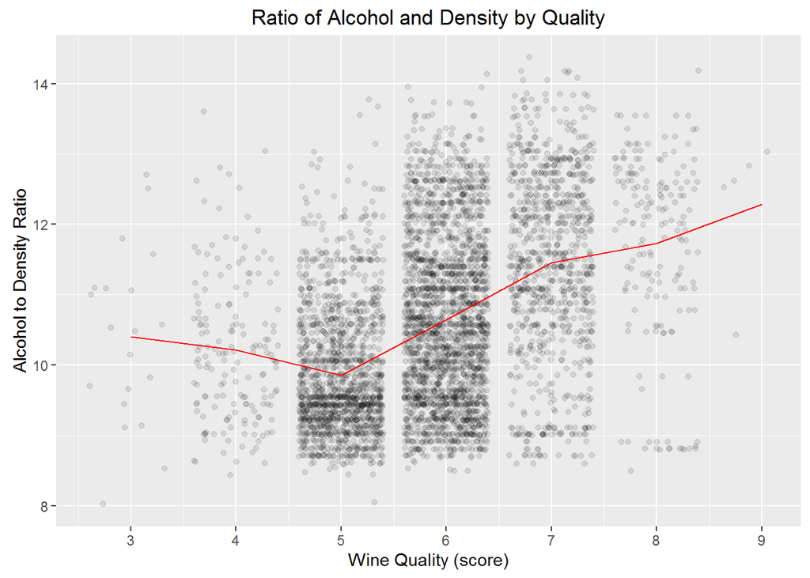

### Plot Two

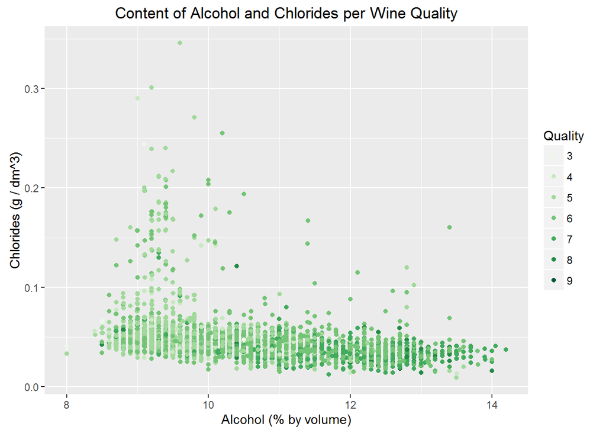

### Description Two

The second plot shows that as the wine quality grows, the content of alcohol becomes higher and the variation of chlorides seems to decrease. Let’s check if the variation of chlorides really declines:

### Plot Three

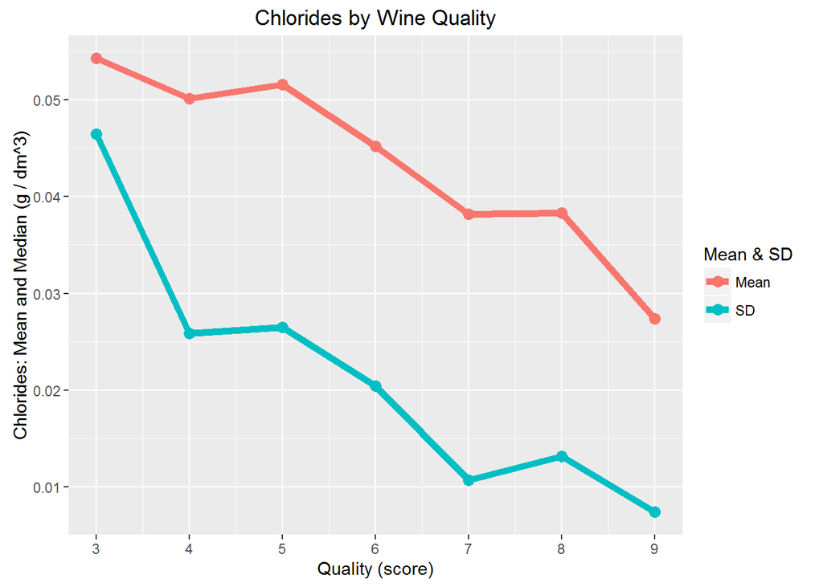

### Description Three

Correct, and the third plot proves it: both the mean and the standard deviation of chlorides decline as the wine quality goes up.

# Reflection

The white wine quality dataset contains information on 4898 wine types acroess eleven variables. First I explored single variables and created some of my own. Then I explored pairs of variables and investigated some of the notes I made on plots. Finally I did some multi-variable research and built a linear model to predict the wine quality.

I didn’t find any strong trends in my dataset. However there were some relationship found between the wine quality and other variables, such as alcohol, density, chlorides and a couple of others. I’d like to note that as the wine quality grows, the amount of chlorides decreases as does the chlorides variation.

I found out that the best wine is either dry or semi-dry.

I noted relationship - and sometimes strong! - between other variables in my dataset, such as density vs. residual.sugar, alcohol vs. density. This relationship can be explained by physics.

I also noted that wines of a moderate quality bring a lot of noise to the plots. It’s easire to see differences in characteristics of bad and good wine if the moderate ones are excluded from the analysis.

My linear model appeared to be poor and doesn’t worth serious mentioning. I really hope to learn more about models in the next course!

I’d like to point out one limitation of the dataset. It appears to contain numerous duplicate values. Before fitting a linear model I removed such rows, but it didn’t greatly improve the model.

Finally I believe that the wine quality measurement is a quite subjective task. There could be other variables that affect the expert’s perception of the quality, such as smell, wine age, etc. Such variables aren’t included into the dataset.